# Prahl_et_al Data Analysis

Jordan Prahl

6/29/2021

## Initialization of count data

First, I must read in all of our ReadsPerCount.out.tab files and combine them into one matrix. The reads files have already been moved into the R working directory. I remove labeling artifacts pulled over from the file path, and then use an adaptation of the limma-voom processing method. Gene information is pulled from org.HS.eg.db.

```r
#devtools::install_github("cmartin/ggConvexHull")
#BiocManager::install(  c("limma", "edgeR", "Glimma", "org.Hs.eg.db", "gplots", "RColorBrewer", "NMF", "BiasedUrn", "devtools", "gridExtra", "cowplot", 'EnhancedVolcano', "clusterProfiler", 'ggnewscale', 'ggupset', "VennDiagram", "motifbreakR", "topGO", "ALL", "enrichplot", "sjplot", "clusterProfiler", "stargazer", "knitr", "VennDiagram", "motifbreakR","gprofiler2"), update=T, ask=F)
#BiocManager::install("sjPlot")
library(edgeR)
library(limma)
library(Glimma)
library(gplots)
library(RColorBrewer)
library(NMF)
library(dplyr)
library(tidyverse)
library(AnnotationDbi)
library(org.Hs.eg.db)
library(reshape2)
library(ggplot2)
library(ggfortify)
library(magrittr)
library(tibble)
library(DataCombine)
library(plyr)
library(EnhancedVolcano)
library(devtools)
library(ggConvexHull)
library(gridExtra)
library(cowplot)
library(topGO)
library(ALL)
library(enrichplot)
library(sjPlot)
library(clusterProfiler)
library(stargazer)
library(knitr)
library(VennDiagram)
library(motifbreakR)
library(readr)
library(gprofiler2)
library(ggpubr)
```

```r
ff <- list.files( path = "./readCounts", pattern = "_ReadsPerGene.out.tab$", full.names = TRUE ) # make a list of file names
counts.files <- lapply( ff, read.table, skip = 4 ) ### read files and create data frame without first 4 rows of meta-data
counts <- sapply( counts.files, function(x) x[ , 2 ] ) ### put counts for each sample into a matrix based on values in the second column (non-stranded counts)
ff <- gsub( "_ReadsPerGene.out.tab", "", ff ) ### remove "_ReadsPerGene.out.tab" from end of file names
ff <- gsub( "./readCounts", "", ff ) ### remove file path from sample names
colnames(counts) <- ff ### add column labels to count matrix (sample names)
row.names(counts) <- counts.files[[1]]$V1 ### add the ensemble ID to rows of count matrix

rownames(counts) <- gsub("\\..+","",rownames(counts)) ### Remove decimals from ENSEMBLE IDs
counts <- unique.matrix(counts) ### Remove duplicates
colnames(counts) <- gsub("/","",colnames(counts)) ### Remove slash from column names
my_dge <- DGEList(counts, genes=rownames(counts)) ### Create a DGE list from counts


# Here we are taking gene information from the org.Hs.eg.db and applying it to our gene list in my_dge
my_dge$genes$Symbol <- mapIds(org.Hs.eg.db,
                         rownames(my_dge),
                         keytype="ENSEMBL", column="SYMBOL")
```

# EdgeR

## Thresholding my count data

Now I have all of my count data with gene info in one object; my_dge. I am going to plot my raw counts against their cpm data to determine what the threshold for low counts should be. In general, a threshold should be chosen for a CPM corresponding to about 10 reads. In the example (https://combine-australia.github.io/RNAseq-R/06-rnaseq-day1.html), they use 0.5 cpm. For my data it looks like that will be closer to 0.125.

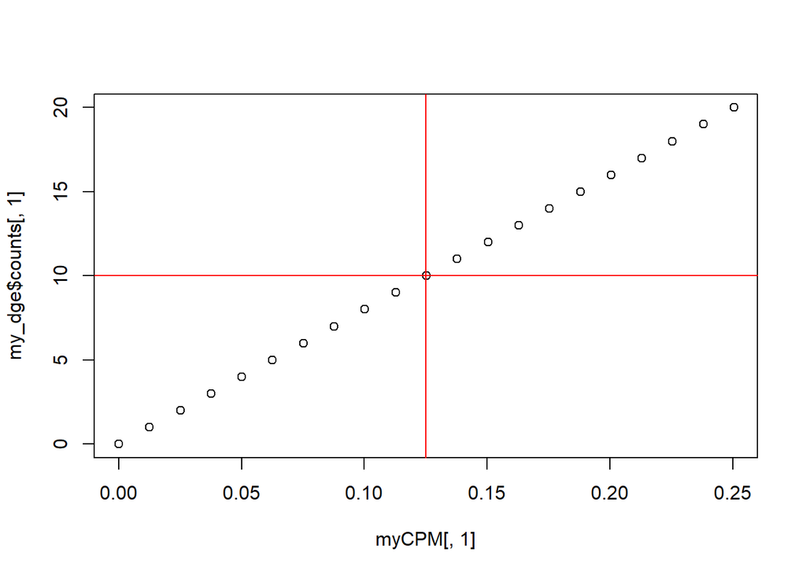

```r
my_dge <- calcNormFactors(my_dge, method = "TMM") # Calculate the normalization factor

myCPM <-cpm(my_dge) #Create an object transformed for counts per million

plot(myCPM[,1],my_dge$counts[,1],ylim=c(0,20),xlim=c(0,0.25))
abline(h=10, v=0.125, col="red")
```

```r
thresh <- myCPM > 0.125 # Apply my newly determined threshold to my cpm data
table(rowSums(thresh))
```

```
##
##     0     1     2     3     4     5     6     7     8     9    10    11    12
## 11495  1863   960   653   512   457   423   391   353   466   420   382   318
##    13    14    15    16    17    18    19    20    21    22    23    24    25
##   316   306   321   326   465   654   388   351   289   284   320   361   439
##    26    27
##   598 14021
```

```r
keep <- rowSums(thresh) >= 2 # keep only those genes which are expressed in at least 2 samples (since we have replicates, anything unique to one sample is considered noise).
summary(keep)
```

```
##    Mode   FALSE    TRUE
## logical   13358   24774
```

```r
my_dge <- my_dge[keep, , keep.lib.sizes=FALSE] #We filtered out any genes not expressed in our samples
dim(my_dge) # confirmed that the TRUE values from our summary(keep) matches the number of rows
```

```
## [1] 24774    27
```

```r
my_dge$samples$Geno <- c("A_","A_","A_","G_","G_","G_","AG","AG","AG", rep("LD", times=9), rep("UD", times=9))
my_dge$samples$ends <- c(rep("paired",times=10), "single", "paired", "single", "paired", rep("single", times=4), "paired", "single", "paired", "single", "paired", rep("single", times=4))
my_dge$samples$crispr <- c(rep("exposed", times=9), rep("naive", times=18))
my_dge$samples$edited <- c(rep("TRUE", times=6), rep("FALSE", times=21))
my_dge$samples$investigator <- c(rep("JP", times=9), rep("TT", times=18))
my_dge$samples$diff <- c(rep("diff", times=18), rep("undiff", times=9))
my_dge$samples$date <- c(rep("202002", times=9), "201702", "201611", "201702", "201611", "201702", "201611", "201611", "201611", "201611", "201702", "201611", "201702", "201611", "201702", "201611", "201611", "201611", "201611")

logcounts <- cpm(my_dge,log=TRUE) # Log transform the cpm data into a new object for later use. Other methods of log transformation will return error from zero-count values. This method provides a slight offset so that we don't lose data.
```

## QC the library sizes

These plots will provide some insight into the library diversity. Ideally, your library sizes will be about equal, but that’s not the case with our data due to the experiments being done in slightly different ways at different times. The diversity is evident from the barplots but shouldn’t be an issue after we correct for cpm (as seen from the normalized box/whisker plots).

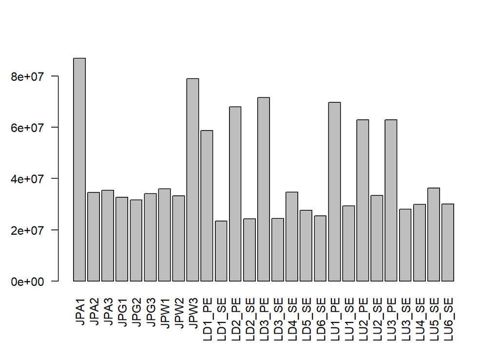

```r
barplot(my_dge$samples$lib.size,names=colnames(my_dge),las=2) # Quality control step, here we see that several of our samples were sequenced to a much greater depth. Normalizing to CPM should address any problems here.
```

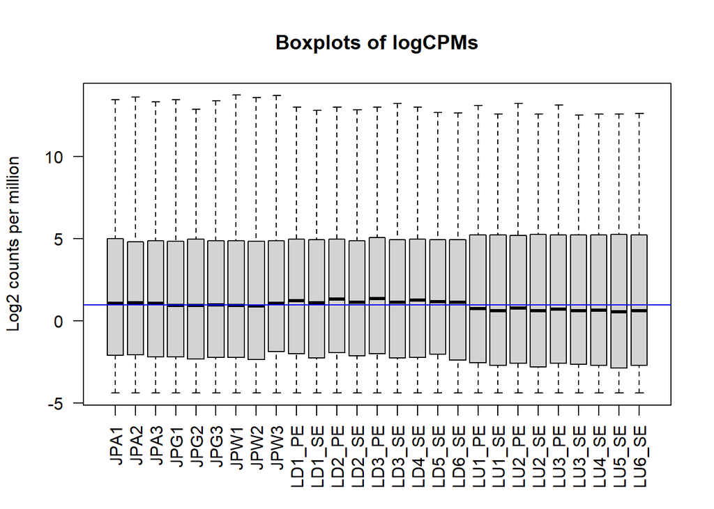

```r
# Another quality control step looking at CPM normalized read-counts. Here we see our transformation has normalized read distribution.
boxplot(logcounts, xlab="", ylab="Log2 counts per million",las=2, main="Boxplots of logCPMs")
abline(h=median(logcounts),col="blue")
```

## Principle component analysis

```r
pca_data <- prcomp(t(logcounts), scale = T)
pData <- data.frame(pca_data$x)
pca_weight <- pca_data$rotation

pData$Geno <- c("A/-","A/-","A/-","G/-","G/-","G/-","A/G","A/G","A/G", rep("LD", times=9), rep("UD", times=9))

var_explained <- pca_data$sdev^2/sum(pca_data$sdev^2) # Add variance to plot axis
```

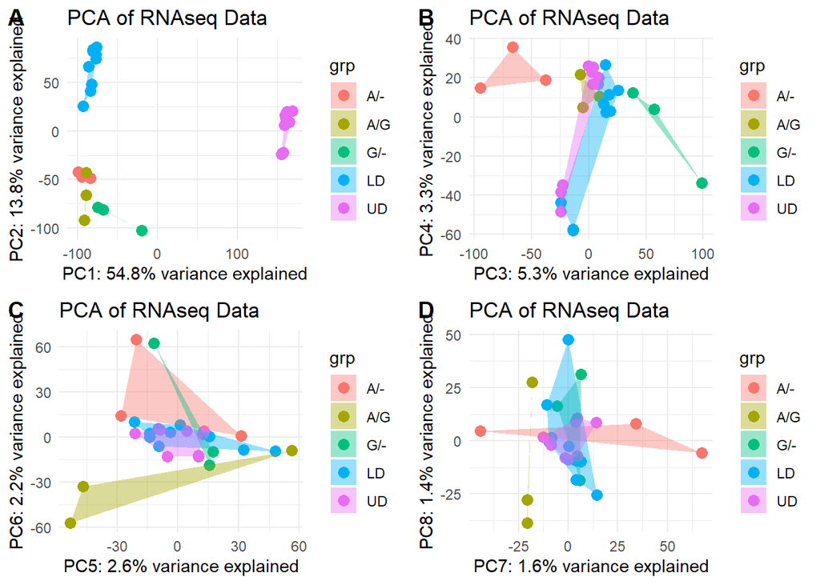

```r
pca.fig <- function(data, x_pc, y_pc, grp) {
  vvar1 <- as.numeric(substring(x_pc,3,3))
  vvar2 <- as.numeric(substring(y_pc,3,3))
  ggplot(data=data, aes_string(x=paste0(x_pc), y=paste0(y_pc))) +
    geom_point(aes(color = grp),size=3) +
    theme_minimal() +
    ggtitle("PCA of RNAseq Data") +
    xlab(paste0(x_pc, ": ", round(var_explained[vvar1]*100,1),"% variance explained")) +
    ylab(paste0(y_pc, ": ", round(var_explained[vvar2]*100,1),"% variance explained")) +
    geom_convexhull(alpha = 0.4,aes(fill = grp))
}

a <- pca.fig(pData, 'PC1','PC2', pData$Geno)
b <- pca.fig(pData, 'PC3', "PC4", pData$Geno)
c <- pca.fig(pData, 'PC5', "PC6", pData$Geno)
d <- pca.fig(pData, 'PC7', "PC8", pData$Geno)

cowplot::plot_grid(a, b,c,d, labels = "AUTO", nrow = 2, ncol = 2)
```

```r
pca.sub <- subset(pData, pData$diff =="diff")
pca.sub
```

```
##  [1] PC1  PC2  PC3  PC4  PC5  PC6  PC7  PC8  PC9  PC10 PC11 PC12 PC13 PC14 PC15
## [16] PC16 PC17 PC18 PC19 PC20 PC21 PC22 PC23 PC24 PC25 PC26 PC27 Geno
## <0 rows> (or 0-length row.names)
```

[figure not shown]

```r
pca.fig(pca.sub, 'PC1','PC2', pca.sub$Geno)
```

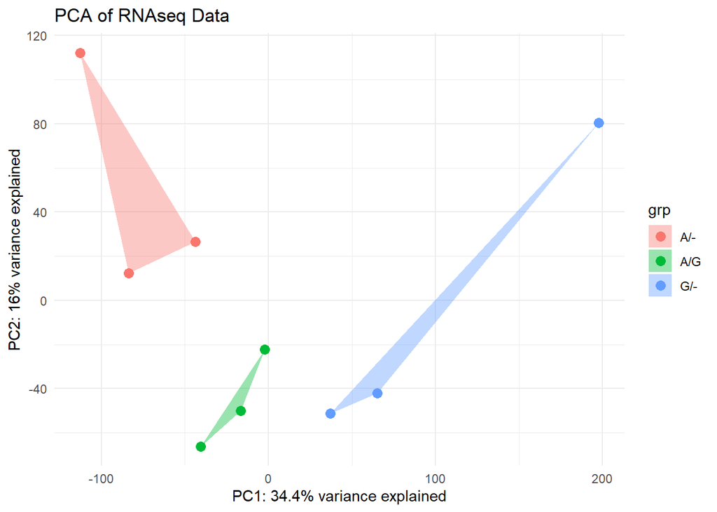

```r
logcounts2 <- logcounts[,1:9]
pca_data2 <- prcomp(t(logcounts2), scale = T)
pData <- data.frame(pca_data2$x)
pca_weight <- data.frame(pca_data$rotation)

pData$Geno <- c("A/-","A/-","A/-","G/-","G/-","G/-","A/G","A/G","A/G")

var_explained <- pca_data2$sdev^2/sum(pca_data$sdev^2) # Add variance to plot axis

a <- pca.fig(pData, 'PC1','PC2', pData$Geno)
a
```

## Combine gene data and count data

```r
expr_data <- data.frame(cpm(my_dge, log=T)) %>%
  rownames_to_column(var="genes") %>%
  dplyr::left_join(data.frame(my_dge$genes), by="genes") %>%
  dplyr::select(genes,Symbol,everything())

colnames(expr_data) <- gsub("X.", "", colnames(expr_data)) # Remove the "X." prefix from sample names

#write.csv(data.frame(expr_data), './cpm_data.csv') ### Save here as a checkpoint
```

## Z-score

Now that I have my data in counts per million, we normalize the genes using a z-score calculation. This calculation takes the observed value, subtracts the average value for each gene, and then divides by the standard deviation per gene to give you a value of deviance from the norm.I am confident that there’s a much easier way to do this, but this is how I did it.

```r
zdata <- expr_data   ### Don't work on the primary data set
zdata$avg <- rowMeans(expr_data[,3:29]) ### Add a column for row averages
zdata$sd <- apply(expr_data[,3:29],1,sd) ### Add a column for row standard deviations
zdata1 <- cbind(zdata[,1:2], ((zdata[,3:29]-zdata[,30])/zdata[,31])) ### Make a new data frame with the gene ID/symbol and Z-scores (observed - average / sd).


#write.csv(data.frame(compData), './20210421_comparison_data.csv') ### Save here as a checkpoint
```

# Limma-Voom method

Working from the limma voom method on github. https://ucdavis-bioinformatics-training.github.io/2018-June-RNA-Seq-Workshop/thursday/DE.html

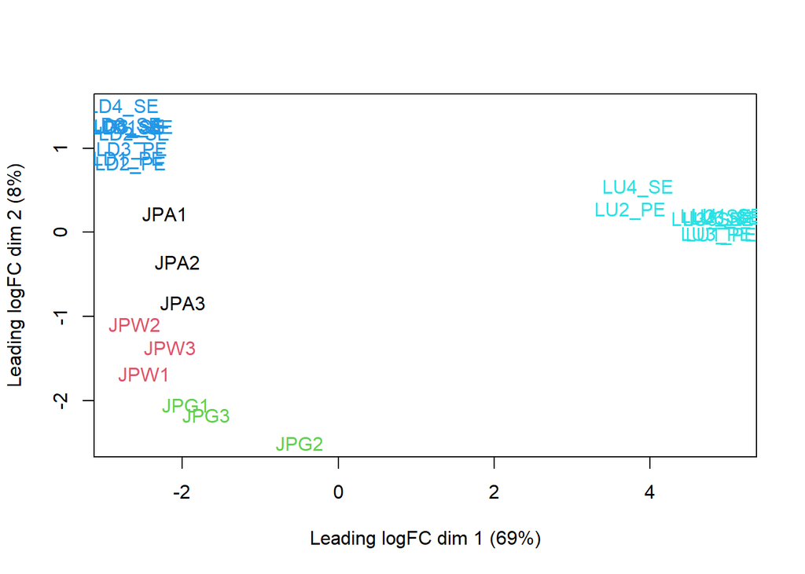

```r
d <- my_dge

# Create a new variable “group” that defines interactions between groups
group <- interaction(d$samples$Geno) # We could use this to look at any of our parameters

# Multidimensional scaling plot
plotMDS(d, col = as.numeric(group))
```

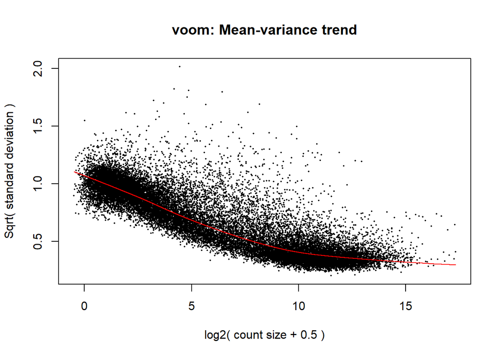

```r
##### Voom transformation and calculation of variance weights

# Specify the model to be fitted. We do this before using voom since voom uses variances of the model residuals (observed - fitted)

mm <- model.matrix(~0 + group)

# The above specifies a model where each coefficient corresponds to a group mean Voom

y <- voom(d, mm, plot = T)
```

### What is voom doing?

1. Counts are transformed to log2 counts per million reads (CPM), where “per million reads” is defined based on the normalization factors we calculated earlier
2. A linear model is fitted to the log2 CPM for each gene, and the residuals are calculated
3. A smoothed curve is fitted to the sqrt(residual standard deviation) by average expression (see red line in plot above)
4. The smoothed curve is used to obtain weights for each gene and sample that are passed into limma along with the log2 CPMs.

More details at https://genomebiology.biomedcentral.com/articles/10.1186/gb-2014-15-2-r29

### Fitting linear models with limma

lmFit fits a linear model using weighted least squares for each gene:

```r
fit <- lmFit(y, mm)
```

Comparisons between groups (log fold-changes) are obtained as contrasts of these fitted linear models:

Specify which groups to compare:

```r
contr <- makeContrasts(groupA_ - groupAG, groupG_ - groupAG, groupA_ - groupG_, groupAG - groupLD, groupLD - groupUD,levels = colnames(coef(fit)))
tmp <- contrasts.fit(fit, contr) # Estimate contrast for each gene
tmp <- eBayes(tmp)
tt0 <- topTable(tmp, sort.by = "F", n = Inf)


contr <- makeContrasts(groupA_ - groupAG, levels = colnames(coef(fit)))
tmp <- contrasts.fit(fit, contr) # Estimate contrast for each gene
tmp1 <- eBayes(tmp)
tt1 <- topTable(tmp1, sort.by = "P", n = Inf)
length(which(tt1$adj.P.Val < 0.05)) # How many differentially expressed genes are there?
```

```
## [1] 3186
```

```r
contr <- makeContrasts(groupG_ - groupAG, levels = colnames(coef(fit)))
tmp <- contrasts.fit(fit, contr) # Estimate contrast for each gene
tmp2 <- eBayes(tmp)
tt2 <- topTable(tmp2, sort.by = "P", n = Inf)
length(which(tt2$adj.P.Val < 0.05))
```

```
## [1] 3083
```

```r
contr <- makeContrasts(groupA_ - groupG_, levels = colnames(coef(fit)))
tmp <- contrasts.fit(fit, contr) # Estimate contrast for each gene
tmp3 <- eBayes(tmp)
tt3 <- topTable(tmp3, sort.by = "P", n = Inf)
length(which(tt3$adj.P.Val < 0.05))
```

```
## [1] 7736
```

```r
contr <- makeContrasts(groupAG - groupLD, levels = colnames(coef(fit)))
tmp <- contrasts.fit(fit, contr) # Estimate contrast for each gene
tmp4 <- eBayes(tmp)
tt4 <- topTable(tmp4, sort.by = "P", n = Inf)
length(which(tt4$adj.P.Val < 0.05))
```

```
## [1] 10611
```

```r
contr <- makeContrasts(groupLD - groupUD, levels = colnames(coef(fit)))
tmp <- contrasts.fit(fit, contr) # Estimate contrast for each gene
tmp5 <- eBayes(tmp)
tt5 <- topTable(tmp5, sort.by = "P", n = Inf)
length(which(tt5$adj.P.Val < 0.05))
```

```
## [1] 20351
```

```r
#write.csv(data.frame(tt1), './20210428_A_v_AG.csv')
#write.csv(data.frame(tt2), './20210428_G_v_AG.csv')
#write.csv(data.frame(tt3), './20210428_A_v_G_.csv')
#write.csv(data.frame(tt4), './20210428_AG_v_LD.csv')
#write.csv(data.frame(tt5), './20210428_LD_v_UD.csv')


multiFull <- merge( merge( merge( merge(merge(tt1, tt2, by="genes", suffixes = c("_A_v_AG","_G_v_AG")), tt3, by="genes", suffixes = c("", "_A_v_G")  ), tt4, by="genes", suffixes = c("", "_AG_v_LD")  ), tt5, by="genes", suffixes = c("", "_LD_v_UD")), zdata1, by="genes", suffixes=c("", "_Zscore"))

compData <- multiFull
colnames(compData) <- c("genes", "Symbol", "logFC_A_v_AG", "AveExpr_A_v_AG", "t_A_v_AG", "P.Value_A_v_AG","adj.P.Val_A_v_AG", "B_A_v_AG", "Symbol_G_v_AG","logFC_G_v_AG", "AveExpr_G_v_AG", "t_G_v_AG", "P.Value_G_v_AG", "adj.P.Val_G_v_AG", "B_G_v_AG", "Symbol_A_v_G", "logFC_A_v_G", "AveExpr_A_v_G","t_A_v_G","P.Value_A_v_G", "adj.P.Val_A_v_G", "B_A_v_G", "Symbol_AG_v_LD", "logFC_AG_v_LD", "AveExpr_AG_v_LD", "t_AG_v_LD", "P.Value_AG_v_LD", "adj.P.Val_AG_v_LD", "B_AG_v_LD","Symbol_LD_v_UD", "logFC_LD_v_UD", "AveExpr_LD_v_UD", "t_LD_v_UD", "P.Value_LD_v_UD", "adj.P.Val_LD_v_UD", "B_LD_v_UD", "Symbol_Zscore", "JPA1", "JPA2", "JPA3", "JPG1", "JPG2", "JPG3","JPW1","JPW2", "JPW3", "LD1_PE", "LD1_SE", "LD2_PE", "LD2_SE", "LD3_PE", "LD3_SE", "LD4_SE", "LD5_SE", "LD6_SE", "LU1_PE", "LU1_SE", "LU2_PE", "LU2_SE", "LU3_PE", "LU3_SE", "LU4_SE", "LU5_SE", "LU6_SE")



#write.csv(data.frame(compData), './20210521_full_comparisons.csv')
```

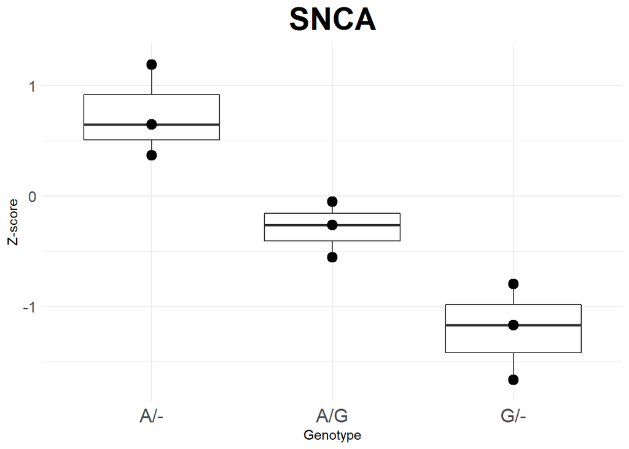

```r
zdata2 <- zdata1
colnames(zdata2) <- c('genes', 'symbol', rep('A/-', 3), rep('G/-', 3), rep('A/G', 3), rep("LD", 9), rep("UD", 9))

{
GENE <- "SNCA"
gdata1 <- subset(zdata2, zdata2[,"symbol"]==GENE)
gdata1 <- gdata1[,-1]
M.zdata <- melt(gdata1)
M.zdata$geno <- c(rep('A/-', 3), rep('G/-', 3), rep('A/G', 3), rep("LD", 9), rep("UD", 9))


my_comparisons <- list(   c("A/-", "A/G"),
                          c("G/-", "A/G"),
                          c("A/-", "G/-")
                      )



compare_means(value ~ geno, data = M.zdata)

g <- ggplot(M.zdata[1:9,], aes(geno,value))
g + geom_boxplot() +
  #stat_compare_means(comparisons = my_comparisons, label = "p.signif") +
  geom_dotplot(binaxis = "y", stackdir = "center") +
  theme_minimal() +
  ylab("Z-score") + xlab("Genotype") + ggtitle(GENE) +
  theme(
    plot.title = element_text(hjust = 0.5, size=25, face="bold"),
    axis.text.x = element_text(size=15),
    axis.text.y = element_text(size=12)
  )
}
```

## Gene Ontology

```r
d <- compData
head(d)
```

```
##             genes   Symbol logFC_A_v_AG AveExpr_A_v_AG   t_A_v_AG
## 1 ENSG00000000003   TSPAN6    0.1162729       5.344708  0.5962862
## 2 ENSG00000000419     DPM1   -0.1397808       5.626299 -1.1483395
## 3 ENSG00000000457    SCYL3    0.1262799       3.703033  1.2097242
## 4 ENSG00000000460 C1orf112    0.2204552       3.110630  1.4590917
## 5 ENSG00000000971      CFH    0.8101387      -4.396039  1.0068882
## 6 ENSG00000001036    FUCA2   -0.3965736       4.506025 -3.2272345
##   P.Value_A_v_AG adj.P.Val_A_v_AG  B_A_v_AG Symbol_G_v_AG logFC_G_v_AG
## 1    0.556001100       0.79851428 -7.037970        TSPAN6    0.7740064
## 2    0.261002676       0.54437450 -6.591239          DPM1    0.1180153
## 3    0.236976301       0.51571072 -6.363605         SCYL3   -0.1978196
## 4    0.156193494       0.40727688 -5.704939      C1orf112    0.4623486
## 5    0.323017769       0.61255681 -5.116754           CFH   -0.1424130
## 6    0.003294491       0.03108062 -2.609906         FUCA2    0.3244185
##   AveExpr_G_v_AG   t_G_v_AG P.Value_G_v_AG adj.P.Val_G_v_AG   B_G_v_AG
```

[output cut: 69 more lines]

```r
{
dd <- subset(d, d$adj.P.Val_G_v_AG < 0.05 & d$logFC_G_v_AG < -1)
ego <- clusterProfiler::enrichGO(gene = dd$genes,
                universe = d$genes,
                keyType = "ENSEMBL",
                OrgDb = org.Hs.eg.db,
                ont = "BP",
                pAdjustMethod = "fdr",
                readable = T   )
ego_G_dn <- ego
sim_G_dn <- clusterProfiler::simplify(ego)
}

head(ego_G_dn)
```

```
##                    ID
## GO:0007600 GO:0007600
## GO:0007156 GO:0007156
## GO:0007606 GO:0007606
## GO:0098742 GO:0098742
## GO:0007608 GO:0007608
## GO:0007411 GO:0007411
##                                                                Description
## GO:0007600                                              sensory perception
## GO:0007156 homophilic cell adhesion via plasma membrane adhesion molecules
## GO:0007606                         sensory perception of chemical stimulus
## GO:0098742       cell-cell adhesion via plasma-membrane adhesion molecules
## GO:0007608                                     sensory perception of smell
## GO:0007411                                                   axon guidance
##            GeneRatio   BgRatio       pvalue     p.adjust       qvalue
## GO:0007600    34/325 413/13920 1.616577e-10 4.066504e-07 3.718667e-07
## GO:0007156    20/325 149/13920 2.662196e-10 4.066504e-07 3.718667e-07
## GO:0007606    14/325  78/13920 2.880224e-09 2.933028e-06 2.682145e-06
## GO:0098742    22/325 223/13920 1.246817e-08 9.522563e-06 8.708031e-06
## GO:0007608    10/325  41/13920 2.472825e-08 1.510896e-05 1.381659e-05
## GO:0007411    21/325 250/13920 4.203799e-07 1.960247e-04 1.792574e-04
##                                                                                                                                                                                                                       geneID
## GO:0007600 USH1C/CNGB1/PPEF1/WHRN/PDE6C/COCH/P2RX3/ASIC1/RIPOR2/SOBP/TG…
## GO:0007156                                                                     CEACAM1/PCDHB4/CDH6/PCDHB10/VSTM2L/CDH11/PCDH15/CDH12/IGFN1/FAT3/PCDHB9/PCDHGA1/PCDHA9/PCDHA8/PCDHGA5/PCDHGA7/PCDHGA8/PCDHGB1/PCDHGA3/PCDHGB3
## GO:0007606                                                                                                                             CNGB1/P2RX3/ASIC1/ADCY3/SLC24A4/GNAL/NCAM2/OR5A1/OR10AD1/OR5AK2/OR2L3/OR2L2/GNAT3/GFY
## GO:0098742                                                           CEACAM1/PCDHB4/CDH6/PCDHB10/VSTM2L/CDH11/PCDH15/CDH12/MPZ/IGFN1/FAT3/ALCAM/PCDHB9/PCDHGA1/PCDHA9/PCDHA8/PCDHGA5/PCDHGA7/PCDHGA8/PCDHGB1/PCDHGA3/PCDHGB3
## GO:0007608                                                                                                                                                    CNGB1/ADCY3/SLC24A4/NCAM2/OR5A1/OR10AD1/OR5AK2/OR2L3/OR2L2/GFY
## GO:0007411                                                                                           NGFR/NRP1/LGI1/EFNB3/DOK4/VSTM2L/PLXNC1/SEMA6D/LHX9/EPHA1/VLDLR/FEZ1/SEMA3D/ISL2/DRGX/ALCAM/BDNF/UNC5C/EPHB3/DCC/PLXNA4
##            Count
## GO:0007600    34
## GO:0007156    20
## GO:0007606    14
## GO:0098742    22
## GO:0007608    10
## GO:0007411    21
```

```r
# TABLE
{
egoTable <- head(ego_G_dn, n=25)
df <- egoTable[,c(1:4,7)]
rownames(df) <- NULL
df %>% dplyr::mutate_if(is.numeric, funs(as.character(signif(., 3)))) %>%
    sjPlot::tab_df(., alternate.rows = T,
           title = "G/- vs A/G; down-regulated gene annotations",
           file = "gsea_G_v_AG_dn.doc"
           )
}
```

G/- vs A/G; down-regulated gene annotations

| ID | Description | GeneRatio | BgRatio | qvalue |
| --- | --- | --- | --- | --- |
| GO:0007600 | sensory perception | 34/325 | 413/13920 | 3.72e-07 |
| GO:0007156 | homophilic cell adhesion via plasma membrane adhesion molecules | 20/325 | 149/13920 | 3.72e-07 |
| GO:0007606 | sensory perception of chemical stimulus | 14/325 | 78/13920 | 2.68e-06 |
| GO:0098742 | cell-cell adhesion via plasma-membrane adhesion molecules | 22/325 | 223/13920 | 8.71e-06 |
| GO:0007608 | sensory perception of smell | 10/325 | 41/13920 | 1.38e-05 |
| GO:0007411 | axon guidance | 21/325 | 250/13920 | 0.000179 |
| GO:0097485 | neuron projection guidance | 21/325 | 251/13920 | 0.000179 |
| GO:0050804 | modulation of chemical synaptic transmission | 25/325 | 347/13920 | 0.000201 |
| GO:0099177 | regulation of trans-synaptic signaling | 25/325 | 348/13920 | 0.000201 |
| GO:0061564 | axon development | 29/325 | 455/13920 | 0.000264 |
| GO:0042391 | regulation of membrane potential | 25/325 | 357/13920 | 0.000264 |
| GO:0007610 | behavior | 27/325 | 439/13920 | 0.00106 |
| GO:0007409 | axonogenesis | 26/325 | 415/13920 | 0.00106 |
| GO:0050906 | detection of stimulus involved in sensory perception | 11/325 | 98/13920 | 0.00347 |
| GO:0050770 | regulation of axonogenesis | 13/325 | 142/13920 | 0.00523 |
| GO:0051606 | detection of stimulus | 17/325 | 232/13920 | 0.00563 |
| GO:0006935 | chemotaxis | 26/325 | 466/13920 | 0.0057 |
| GO:0009593 | detection of chemical stimulus | 9/325 | 71/13920 | 0.0057 |
| GO:0042330 | taxis | 26/325 | 467/13920 | 0.0057 |
| GO:0071805 | potassium ion transmembrane transport | 14/325 | 170/13920 | 0.00635 |
| GO:0001508 | action potential | 11/325 | 116/13920 | 0.0112 |
| GO:0006813 | potassium ion transport | 14/325 | 185/13920 | 0.014 |
| GO:0050954 | sensory perception of mechanical stimulus | 12/325 | 141/13920 | 0.014 |
| GO:0016339 | calcium-dependent cell-cell adhesion via plasma membrane cell adhesion molecules | 6/325 | 35/13920 | 0.0165 |
| GO:0008037 | cell recognition | 10/325 | 107/13920 | 0.0222 |

## Volcano plots

```r
nearLab <- c("SNCA", "CCSER1", "NAP1L5", "FAM13A-AS1", "FAM13A", "MMRN1", "GPRIN3", "TIGD2", "HERC3")
foxLab <- c("FOXO1", "FOXA3", "FOXA1", "FOXP2", "FOXO4", "FOXD1", "FOXC1", "FOXA2", "FOXO3", "FOXF2")
lab1 <- c("none")


EV_func <- function(data, xx, yy, xxlm, yylm, glab, tit1) {
  EnhancedVolcano::EnhancedVolcano(data,
              lab= data$Symbol,
              x= xx,
              y= yy,
              pCutoff = 0.05,
              FCcutoff = 1,
              selectLab = glab,
              colAlpha = 0.5,
              xlim = xxlm,
              ylim = yylm,
              legendPosition = "null",
              legendLabSize = 12,
              col = c("grey", "grey", "grey", "red"),
              drawConnectors = T,
              widthConnectors = 1,
              boxedLabels = F,
              subtitle = tit1,
              title = "Differential expression",
              #caption = bquote(~Log[2]~ "fold change cutoff, 1; p-value cutoff, 0.05"),
  )
  }
```

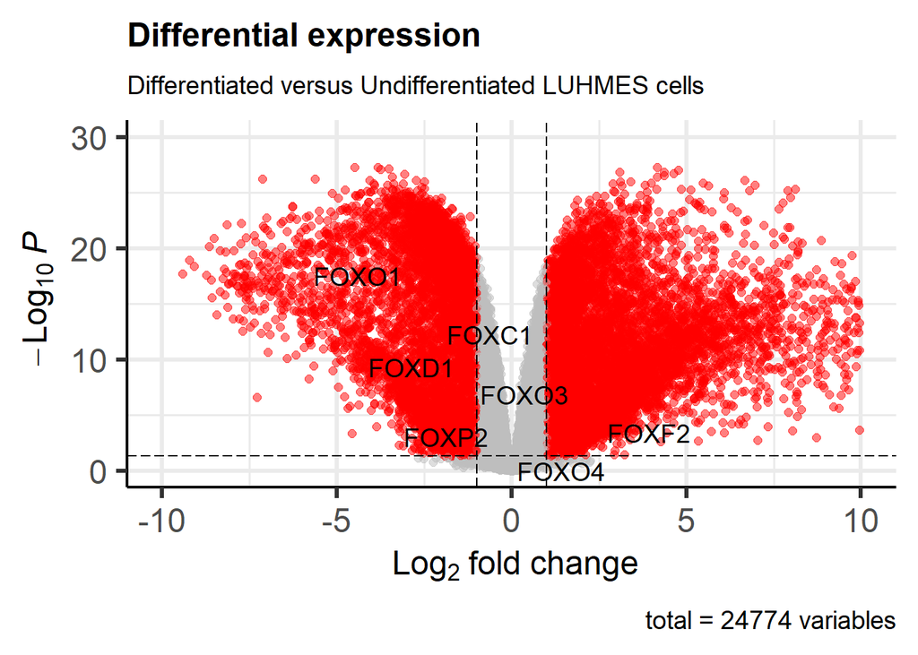

```r
EV_func(compData, 'logFC_LD_v_UD', 'adj.P.Val_LD_v_UD', c(-10,10), c(0,30), foxLab, "Differentiated versus Undifferentiated LUHMES cells")
```

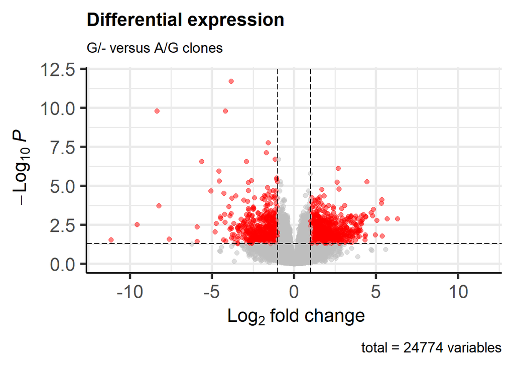

```r
EV_func(compData, 'logFC_G_v_AG', 'adj.P.Val_G_v_AG', c(-11.5,11.5), c(0,12), lab1, "G/- versus A/G clones")
```

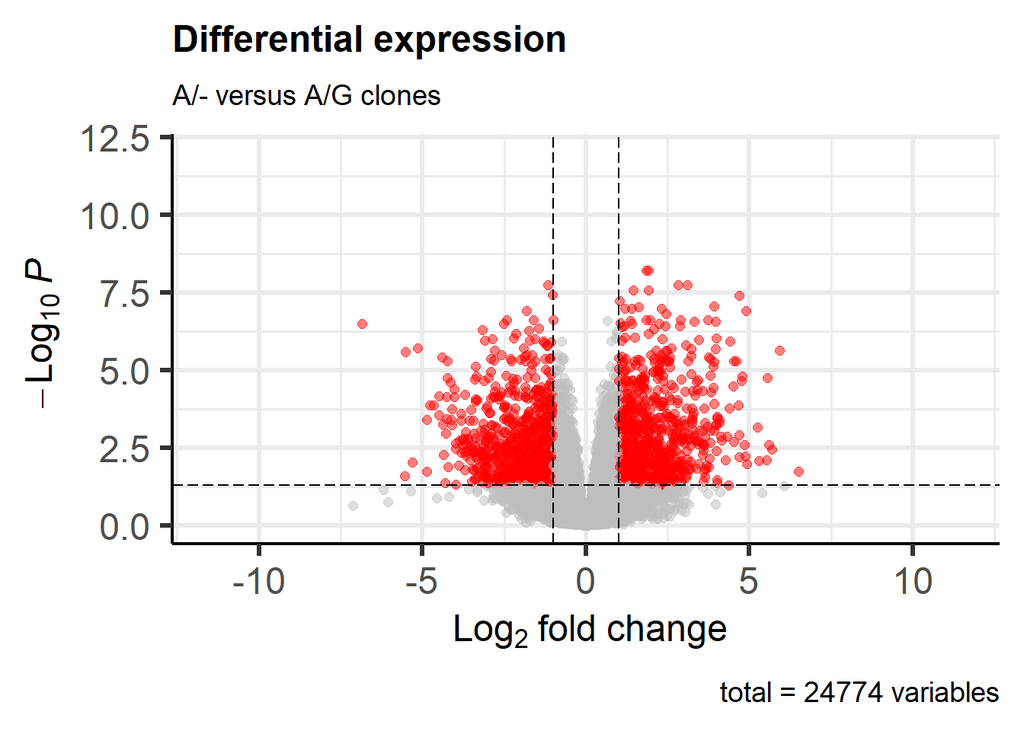

```r
EV_func(compData, 'logFC_A_v_AG', 'adj.P.Val_A_v_AG', c(-11.5,11.5), c(0,12), lab1, "A/- versus A/G clones")
```

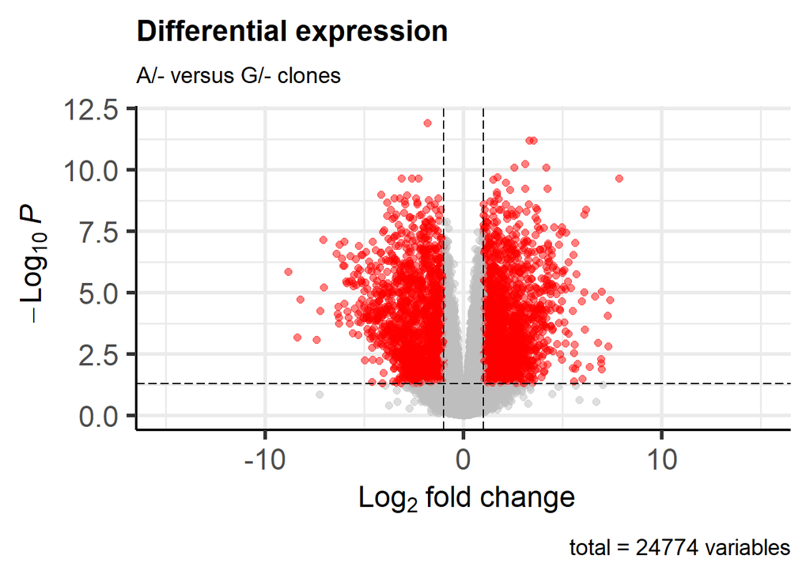

```r
EV_func(compData, 'logFC_A_v_G', 'adj.P.Val_A_v_G', c(-15,15), c(0,12), lab1, "A/- versus G/- clones")
```

## MotifbreakR

```r
#BiocManager::install(c('SNPlocs.Hsapiens.dbSNP142.GRCh37', "BSgenome.Hsapiens.UCSC.hg19"))

library(MotifDb)
library(BSgenome)
library(SNPlocs.Hsapiens.dbSNP142.GRCh37) # dbSNP137 in hg19
library(BSgenome.Hsapiens.UCSC.hg19)

MotifDb
```

```
## MotifDb object of length 10701
## | Created from downloaded public sources: 2013-Aug-30
## | 10701 position frequency matrices from 21 sources:
## |         cisbp_1.02:  874
## |    FlyFactorSurvey:  614
## |        HOCOMOCOv10: 1066
## | HOCOMOCOv11-core-A:  181
## | HOCOMOCOv11-core-B:   84
## | HOCOMOCOv11-core-C:  135
## | HOCOMOCOv11-secondary-A:   46
## | HOCOMOCOv11-secondary-B:   19
## | HOCOMOCOv11-secondary-C:   13
## | HOCOMOCOv11-secondary-D:  290
## |              HOMER:  332
## |               hPDI:  437
## |        JASPAR_2014:  592
## |        JASPAR_CORE:  459
## |         jaspar2016: 1209
## |         jaspar2018: 1564
## |          jolma2013:  843
## |             ScerTF:  196
## |            stamlab:  683
## |       SwissRegulon:  684
## |           UniPROBE:  380
## | 61 organism/s
## |           Hsapiens: 5384
## |          Mmusculus: 1411
## |      Dmelanogaster: 1287
## |        Scerevisiae: 1051
## |          Athaliana:  803
## |           Celegans:   90
## |              other:  675
## Scerevisiae-cisbp_1.02-M0001_1.02
## Scerevisiae-cisbp_1.02-M0002_1.02
## Scerevisiae-cisbp_1.02-M0003_1.02
## Csativa-cisbp_1.02-M0004_1.02
## Athaliana-cisbp_1.02-M0005_1.02
## ...
## Mmusculus-UniPROBE-Zfp740.UP00022
## Mmusculus-UniPROBE-Zic1.UP00102
## Mmusculus-UniPROBE-Zic2.UP00057
## Mmusculus-UniPROBE-Zic3.UP00006
## Mmusculus-UniPROBE-Zscan4.UP00026
```

```r
pca.snps <- "rs356182"
snps.mb <- motifbreakR::snps.from.rsid(rsid = pca.snps,
                          dbSNP = SNPlocs.Hsapiens.dbSNP142.GRCh37,
                          search.genome = BSgenome.Hsapiens.UCSC.hg19)

snps.mb
```

```
## GRanges object with 1 range and 3 metadata columns:
##            seqnames    ranges strand |      SNP_id            REF
##               <Rle> <IRanges>  <Rle> | <character> <DNAStringSet>
##   rs356182     chr4  90626111      * |    rs356182              G
##                       ALT
##            <DNAStringSet>
##   rs356182              A
##   -------
##   seqinfo: 1 sequence from hg19 genome
```

```r
table(mcols(MotifDb)$organism, mcols(MotifDb)$dataSource)
```

[output not shown]

[output cut: 1247 more lines]

[output not shown]

```r
data(motifbreakR_motif)
motifbreakR_motif
```

```
## MotifDb object of length 2817
## | Created from downloaded public sources: 2013-Aug-30
## | 2817 position frequency matrices from 4 sources:
## |       ENCODE-motif: 2065
## |         FactorBook:   79
## |           HOCOMOCO:  426
## |              HOMER:  247
## | 1 organism/s
## |           Hsapiens: 2817
## Hsapiens-ENCODE-motifs-SIX5_disc1
## Hsapiens-ENCODE-motifs-MYC_disc1
## Hsapiens-ENCODE-motifs-SRF_disc1
## Hsapiens-ENCODE-motifs-AP1_disc1
## Hsapiens-ENCODE-motifs-SIX5_disc2
## ...
## Hsapiens-HOMER-yy1.motif
## Hsapiens-HOMER-zbtb33.motif
## Hsapiens-HOMER-zfx.motif
## Hsapiens-HOMER-znf263.motif
## Hsapiens-HOMER-znf711.motif
```

```r
data(hocomoco)
hocomoco
```

```
## MotifDb object of length 426
## | Created from downloaded public sources: 2013-Aug-30
## | 426 position frequency matrices from 1 source:
## |           HOCOMOCO:  426
## | 1 organism/s
## |           Hsapiens:  426
## Hsapiens-HOCOMOCO-AHR_si
## Hsapiens-HOCOMOCO-AIRE_f2
## Hsapiens-HOCOMOCO-ALX1_si
## Hsapiens-HOCOMOCO-ANDR_do
## Hsapiens-HOCOMOCO-AP2A_f2
## ...
## Hsapiens-HOCOMOCO-ZN333_f1
## Hsapiens-HOCOMOCO-ZN350_f1
## Hsapiens-HOCOMOCO-ZN384_f1
## Hsapiens-HOCOMOCO-ZN423_f1
## Hsapiens-HOCOMOCO-ZN589_f1
```

```r
results <- motifbreakR::motifbreakR(snpList = snps.mb, filterp = TRUE,
                       pwmList = motifbreakR_motif,
                       threshold = 1e-4,
                       #method = "ic",
                       bkg = c(A=0.25, C=0.25, G=0.25, T=0.25),
                       #BPPARAM = BiocParallel::bpparam()
                       )

results
```

```
## GRanges object with 71 ranges and 19 metadata columns:
##            seqnames    ranges strand |      SNP_id            REF
##               <Rle> <IRanges>  <Rle> | <character> <DNAStringSet>
##   rs356182     chr4  90626111      - |    rs356182              G
##   rs356182     chr4  90626111      + |    rs356182              G
##   rs356182     chr4  90626111      - |    rs356182              G
##   rs356182     chr4  90626111      + |    rs356182              G
##   rs356182     chr4  90626111      - |    rs356182              G
##        ...      ...       ...    ... .         ...            ...
##   rs356182     chr4  90626111      - |    rs356182              G
##   rs356182     chr4  90626111      + |    rs356182              G
##   rs356182     chr4  90626111      - |    rs356182              G
##   rs356182     chr4  90626111      - |    rs356182              G
##   rs356182     chr4  90626111      - |    rs356182              G
##                       ALT     varType motifPos  geneSymbol   dataSource
##            <DNAStringSet> <character>   <list> <character>  <character>
##   rs356182              A         SNV    -5, 6       FOXP1        HOMER
##   rs356182              A         SNV    -3, 7       FOXO4 ENCODE-motif
##   rs356182              A         SNV    -6, 6       FOXF1 ENCODE-motif
##   rs356182              A         SNV    -8, 8       FOXK1 ENCODE-motif
##   rs356182              A         SNV    -5, 6       FOXQ1 ENCODE-motif
##        ...            ...         ...      ...         ...          ...
##   rs356182              A         SNV  -10,  3        <NA>        HOMER
##   rs356182              A         SNV  -11,  5        <NA>        HOMER
##   rs356182              A         SNV    -2, 6         SRY     HOCOMOCO
##   rs356182              A         SNV    -5, 7       FOXO3     HOCOMOCO
##   rs356182              A         SNV    -7, 3       FOXF2     HOCOMOCO
##                      providerName  providerId               seqMatch    pctRef
##                       <character> <character>            <character> <numeric>
##   rs356182 FOXP1(Forkhead)/H9-F..       FOXP1      ttTgcaatgtaaaca..  0.850491
##   rs356182       FOXO4_known_ref1     FOXO4_1       tTgcaatgtaaaca..  0.796387
##   rs356182       FOXF1_known_ref1     FOXF1_1     cttTgcaatgtaaaca..  0.737526
##   rs356182       FOXK1_known_ref1     FOXK1_1 tttgcttTgcaatgtaaaca..  0.863343
##   rs356182       FOXQ1_known_ref1     FOXQ1_1      ttTgcaatgtaaaca..  0.740183
##        ...                    ...         ...                    ...       ...
##   rs356182 X-box(HTH)/NPC-H3K4m..       X-box    gcttTgcaatgtaaaca..  0.721848
##   rs356182 Fox:Ebox(Forkhead,bH..    Fox:Ebox tttgcttTgcaatgtaaaca..  0.856905
##   rs356182                 SRY_f1   SRY_HUMAN         gcaatgtaaaca..  0.856486
##   rs356182               FOXO3_si FOXO3_HUMAN     cttTgcaatgtaaaca..  0.820268
##   rs356182               FOXF2_f1 FOXF2_HUMAN       tTgcaatgtaaaca..  0.874148
```

[output cut: 13 more lines]

```
##            alleleDiff      effect
##             <numeric> <character>
##   rs356182   0.899788      strong
##   rs356182   0.907029      strong
##   rs356182   0.907029      strong
##   rs356182   0.856527      strong
##   rs356182   0.907029      strong
##        ...        ...         ...
##   rs356182   0.617085        weak
##   rs356182   0.450816        weak
##   rs356182   0.475656        weak
##   rs356182   0.937166      strong
##   rs356182   0.714816      strong
##   -------
##   seqinfo: 1 sequence from hg19 genome
```

```r
results.p <- calculatePvalue(results)

results2 <- results.p[order(results.p$alleleDiff)]
results2
```

```
## GRanges object with 71 ranges and 19 metadata columns:
##            seqnames    ranges strand |      SNP_id            REF
##               <Rle> <IRanges>  <Rle> | <character> <DNAStringSet>
##   rs356182     chr4  90626111      - |    rs356182              G
##   rs356182     chr4  90626111      + |    rs356182              G
##   rs356182     chr4  90626111      - |    rs356182              G
##   rs356182     chr4  90626111      - |    rs356182              G
##   rs356182     chr4  90626111      + |    rs356182              G
##        ...      ...       ...    ... .         ...            ...
##   rs356182     chr4  90626111      - |    rs356182              G
##   rs356182     chr4  90626111      - |    rs356182              G
##   rs356182     chr4  90626111      - |    rs356182              G
##   rs356182     chr4  90626111      - |    rs356182              G
##   rs356182     chr4  90626111      - |    rs356182              G
##                       ALT     varType motifPos  geneSymbol   dataSource
##            <DNAStringSet> <character>   <list> <character>  <character>
##   rs356182              A         SNV    -6, 1         AP3 ENCODE-motif
##   rs356182              A         SNV  -11,  5        <NA>        HOMER
##   rs356182              A         SNV    -2, 6         SRY     HOCOMOCO
##   rs356182              A         SNV    -1, 7       FOXP3     HOCOMOCO
##   rs356182              A         SNV    -4, 8       FOXL1 ENCODE-motif
##        ...            ...         ...      ...         ...          ...
##   rs356182              A         SNV    -7, 4       FOXA2     HOCOMOCO
##   rs356182              A         SNV    -4, 4       FOXO4     HOCOMOCO
##   rs356182              A         SNV    -8, 7       FOXO1     HOCOMOCO
##   rs356182              A         SNV    -5, 7       FOXO3     HOCOMOCO
##   rs356182              A         SNV    -7, 3       FOXA1     HOCOMOCO
##                      providerName  providerId               seqMatch    pctRef
##                       <character> <character>            <character> <numeric>
##   rs356182         AP3_known_ref1       AP3_1          caatgtagaca..  0.958823
##   rs356182 Fox:Ebox(Forkhead,bH..    Fox:Ebox tttgcttTgcaatgtaaaca..  0.856905
##   rs356182                 SRY_f1   SRY_HUMAN         gcaatgtaaaca..  0.856486
##   rs356182               FOXP3_f1 FOXP3_HUMAN         gcaatgtaaaca..  0.818257
##   rs356182       FOXL1_known_ref5     FOXL1_5     cttTgcaatgtaaaca..  0.763158
##        ...                    ...         ...                    ...       ...
##   rs356182               FOXA2_f1 FOXA2_HUMAN      ttTgcaatgtaaaca..  0.821955
##   rs356182               FOXO4_f1 FOXO4_HUMAN         gcaatgtaaaca..  0.787102
##   rs356182               FOXO1_si FOXO1_HUMAN  ttgcttTgcaatgtaaaca..  0.788680
##   rs356182               FOXO3_si FOXO3_HUMAN     cttTgcaatgtaaaca..  0.820268
##   rs356182               FOXA1_f1 FOXA1_HUMAN       tTgcaatgtaaaca..  0.818144
```

[output cut: 13 more lines]

```
##            alleleDiff      effect
##             <numeric> <character>
##   rs356182  -0.907029      strong
##   rs356182   0.450816        weak
##   rs356182   0.475656        weak
##   rs356182   0.525625        weak
##   rs356182   0.573607        weak
##        ...        ...         ...
##   rs356182   0.927237      strong
##   rs356182   0.932224      strong
##   rs356182   0.932680      strong
##   rs356182   0.937166      strong
##   rs356182   0.940941      strong
##   -------
##   seqinfo: 1 sequence from hg19 genome
```

```r
results3 <- head(results2, n=10)
results3
```

```
## GRanges object with 10 ranges and 19 metadata columns:
##            seqnames    ranges strand |      SNP_id            REF
##               <Rle> <IRanges>  <Rle> | <character> <DNAStringSet>
##   rs356182     chr4  90626111      - |    rs356182              G
##   rs356182     chr4  90626111      + |    rs356182              G
##   rs356182     chr4  90626111      - |    rs356182              G
##   rs356182     chr4  90626111      - |    rs356182              G
##   rs356182     chr4  90626111      + |    rs356182              G
##   rs356182     chr4  90626111      - |    rs356182              G
##   rs356182     chr4  90626111      + |    rs356182              G
##   rs356182     chr4  90626111      - |    rs356182              G
##   rs356182     chr4  90626111      + |    rs356182              G
##   rs356182     chr4  90626111      - |    rs356182              G
##                       ALT     varType motifPos  geneSymbol   dataSource
##            <DNAStringSet> <character>   <list> <character>  <character>
##   rs356182              A         SNV    -6, 1         AP3 ENCODE-motif
##   rs356182              A         SNV  -11,  5        <NA>        HOMER
##   rs356182              A         SNV    -2, 6         SRY     HOCOMOCO
##   rs356182              A         SNV    -1, 7       FOXP3     HOCOMOCO
##   rs356182              A         SNV    -4, 8       FOXL1 ENCODE-motif
##   rs356182              A         SNV  -12,  2        <NA>        HOMER
##   rs356182              A         SNV    -3, 3       FOXK1 ENCODE-motif
##   rs356182              A         SNV  -10,  3        <NA>        HOMER
##   rs356182              A         SNV    -6, 9       FOXJ1 ENCODE-motif
##   rs356182              A         SNV    -7, 3       EP300 ENCODE-motif
##                      providerName          providerId               seqMatch
##                       <character>         <character>            <character>
##   rs356182         AP3_known_ref1               AP3_1          caatgtagaca..
##   rs356182 Fox:Ebox(Forkhead,bH..            Fox:Ebox tttgcttTgcaatgtaaaca..
##   rs356182                 SRY_f1           SRY_HUMAN         gcaatgtaaaca..
##   rs356182               FOXP3_f1         FOXP3_HUMAN         gcaatgtaaaca..
##   rs356182       FOXL1_known_ref5             FOXL1_5     cttTgcaatgtaaaca..
##   rs356182 OCT4-SOX2-TCF-NANOG(.. OCT4-SOX2-TCF-NANOG   tgcttTgcaatgtaaaca..
##   rs356182       FOXK1_known_ref4             FOXK1_4           aatgtaaaca..
##   rs356182 X-box(HTH)/NPC-H3K4m..               X-box    gcttTgcaatgtaaaca..
##   rs356182       FOXJ1_known_ref2             FOXJ1_2  ttgcttTgcaatgtaaaca..
##   rs356182            EP300_disc3         EP300_disc3       tTgcaatgtaaaca..
##               pctRef    pctAlt  scoreRef  scoreAlt   Refpvalue   Altpvalue
##            <numeric> <numeric> <numeric> <numeric>   <numeric>   <numeric>
##   rs356182  0.958823  0.721569   3.72950   2.82248 6.10352e-05 2.25983e-02
```

[output cut: 8 more lines]

```
##   rs356182  0.838220  0.964939   4.35882   4.98648 5.17368e-04 4.76837e-06
##               altPos alleleDiff      effect
##            <integer>  <numeric> <character>
##   rs356182         1  -0.907029      strong
##   rs356182         1   0.450816        weak
##   rs356182         1   0.475656        weak
##   rs356182         1   0.525625        weak
##   rs356182         1   0.573607        weak
##   rs356182         1   0.575844        weak
##   rs356182         1   0.598276        weak
##   rs356182         1   0.617085        weak
##   rs356182         1   0.627308        weak
##   rs356182         1   0.627653        weak
##   -------
##   seqinfo: 1 sequence from hg19 genome
```

```r
olap <- c("FOXA1", "FOXC1", "FOXD1")
results4 <- subset(results, results$effect == "strong" & results$dataSource == "HOCOMOCO")
results4 <- calculatePvalue(results4)
results4
```

```
## GRanges object with 10 ranges and 19 metadata columns:
##            seqnames    ranges strand |      SNP_id            REF
##               <Rle> <IRanges>  <Rle> | <character> <DNAStringSet>
##   rs356182     chr4  90626111      - |    rs356182              G
##   rs356182     chr4  90626111      - |    rs356182              G
##   rs356182     chr4  90626111      - |    rs356182              G
##   rs356182     chr4  90626111      - |    rs356182              G
##   rs356182     chr4  90626111      - |    rs356182              G
##   rs356182     chr4  90626111      - |    rs356182              G
##   rs356182     chr4  90626111      - |    rs356182              G
##   rs356182     chr4  90626111      - |    rs356182              G
##   rs356182     chr4  90626111      - |    rs356182              G
##   rs356182     chr4  90626111      - |    rs356182              G
##                       ALT     varType motifPos  geneSymbol  dataSource
##            <DNAStringSet> <character>   <list> <character> <character>
##   rs356182              A         SNV    -8, 7       FOXO1    HOCOMOCO
##   rs356182              A         SNV    -8, 4       FOXA3    HOCOMOCO
##   rs356182              A         SNV    -7, 3       FOXA1    HOCOMOCO
##   rs356182              A         SNV    -4, 4       FOXP2    HOCOMOCO
##   rs356182              A         SNV    -4, 4       FOXO4    HOCOMOCO
##   rs356182              A         SNV    -8, 6       FOXD1    HOCOMOCO
##   rs356182              A         SNV    -8, 6       FOXC1    HOCOMOCO
##   rs356182              A         SNV    -7, 4       FOXA2    HOCOMOCO
##   rs356182              A         SNV    -5, 7       FOXO3    HOCOMOCO
##   rs356182              A         SNV    -7, 3       FOXF2    HOCOMOCO
##            providerName  providerId               seqMatch    pctRef    pctAlt
##             <character> <character>            <character> <numeric> <numeric>
##   rs356182     FOXO1_si FOXO1_HUMAN  ttgcttTgcaatgtaaaca..  0.788680  0.938970
##   rs356182     FOXA3_f1 FOXA3_HUMAN     cttTgcaatgtaaaca..  0.771192  0.945068
##   rs356182     FOXA1_f1 FOXA1_HUMAN       tTgcaatgtaaaca..  0.818144  0.971930
##   rs356182     FOXP2_si FOXP2_HUMAN         gcaatgtaaaca..  0.830183  0.998963
##   rs356182     FOXO4_f1 FOXO4_HUMAN         gcaatgtaaaca..  0.787102  0.949056
##   rs356182     FOXD1_si FOXD1_HUMAN   tgcttTgcaatgtaaaca..  0.792424  0.930249
##   rs356182     FOXC1_f1 FOXC1_HUMAN   tgcttTgcaatgtaaaca..  0.790275  0.898425
##   rs356182     FOXA2_f1 FOXA2_HUMAN      ttTgcaatgtaaaca..  0.821955  0.974819
##   rs356182     FOXO3_si FOXO3_HUMAN     cttTgcaatgtaaaca..  0.820268  0.981122
##   rs356182     FOXF2_f1 FOXF2_HUMAN       tTgcaatgtaaaca..  0.874148  0.992782
##             scoreRef  scoreAlt   Refpvalue   Altpvalue    altPos alleleDiff
##            <numeric> <numeric>   <numeric>   <numeric> <integer>  <numeric>
##   rs356182   5.24751   6.18019 0.001089086 8.47178e-06         1   0.932680
```

[output cut: 8 more lines]

```
##   rs356182   5.38324   6.09806 0.000118971 1.66893e-06         1   0.714816
##                 effect
##            <character>
##   rs356182      strong
##   rs356182      strong
##   rs356182      strong
##   rs356182      strong
##   rs356182      strong
##   rs356182      strong
##   rs356182      strong
##   rs356182      strong
##   rs356182      strong
##   rs356182      strong
##   -------
##   seqinfo: 1 sequence from hg19 genome
```

```r
results5 <- subset(results4, results4$geneSymbol == c("FOXA1", "FOXC1", "FOXD1"))
```

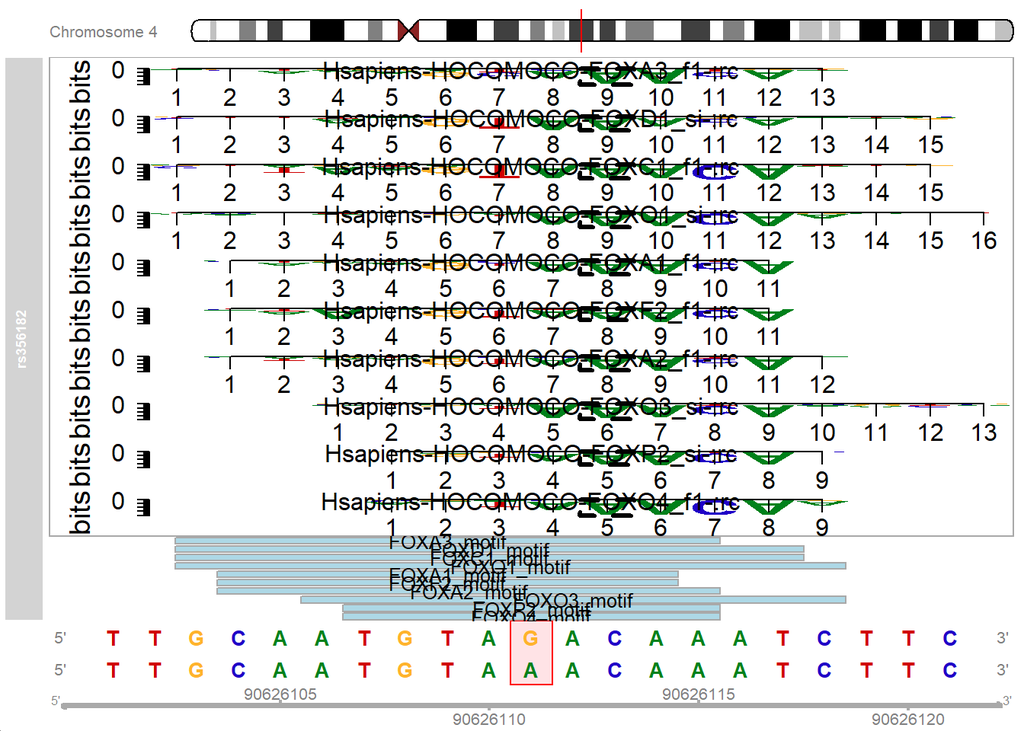

```r
plotMB(results = results4, rsid = "rs356182", effect = "strong")
```

```r
write.csv(data.frame(results2), './20210623_motifbreakR_results_full.csv')
```